# MA 321-7 ; Applied Statistics ; Team Project ; Group 2 - Team C

2024-03-14

### MA321-7-SP: Team Project ; Group 2 - Team C

#### Loading Necessary Libraries:

```r
library(zoo)
library(caret)
```

```r
library(stats)
library(ggplot2)
library(reshape2)
library(randomForest)   # For Random Forest evaluation
library(rpart)          # For Decision Tree
library(MASS)           # For LDA & generalized analysis
library(car)
library(e1071)          # For Naive Bayes
library(class)          # For k-NN
library(glmnet)         # For Logistic Regression
library(tidymodels)     # For modeling and evaluation
library(pROC)           # For ROC curve analysis
library(xgboost)        # For XGBoost analysis
library(kernlab)
library(pROC)
library(Rtsne)
library(ggplot2)
```

#### Data Exploration and Analysis:

**Loading and Understanding the Raw Dataset:**

```r
# Setting up the working directory:
setwd("C://Users//Maisam//Downloads//4. Assignments//MA 321-7  ; Applied Statistics ; Team Project")
getwd()
```

```
## [1] "C:/Users/Maisam/Downloads/4. Assignments/MA 321-7  ; Applied Statistics ; Team Project"
```

```r
# Loading the raw dataset
initial_data <- read.csv(file="gene-expression-invasive-vs-noninvasive-cancer.csv")

# Understanding the structure of raw dataset
str(initial_data[,1:10])
```

```
## 'data.frame':    78 obs. of  10 variables:
##  $ J00129        : num  -0.448 -0.48 -0.568 -0.819 -0.112 -0.391 -0.624 -0.528 -0.811 -0.839 ...
##  $ Contig29982_RC: num  -0.296 -0.512 -0.411 -0.267 -0.67 -0.31 -0.12 -0.447 -0.536 2 ...
##  $ Contig42854   : num  -0.1 -0.031 -0.398 0.023 0.421 -0.06 -0.236 -0.254 -0.211 0.147 ...
##  $ Contig42014_RC: num  -0.177 -0.075 0.116 -0.23 -0.19 -0.164 -0.175 0.017 -0.201 -0.325 ...
##  $ Contig27915_RC: num  -0.107 -0.104 -0.092 0.198 0.032 -0.173 0.253 0.654 0.287 -0.303 ...
##  $ Contig20156_RC: num  -0.11 -0.234 -0.166 -0.51 0.281 -0.034 -0.125 0.364 -0.08 -0.061 ...
##  $ Contig50634_RC: num  -0.095 -0.225 0.036 0.529 0.31 -0.091 -0.127 0.068 -0.15 0.097 ...
##  $ Contig42615_RC: num  -0.076 -0.094 0.397 0.354 0.056 0.036 -0.02 0.181 0.045 0.006 ...
##  $ Contig56678_RC: num  -0.134 0.115 -0.194 -0.261 0.116 0.346 0.047 -1.14 -0.11 0.176 ...
##  $ Contig48659_RC: num  -0.14 0.019 -0.128 0.012 0.074 0.007 -0.15 -0.111 -0.072 -0.084 ...
```

```r
# Verifying the class label column name
dimnames(initial_data)[[2]][4947:4949]
```

```
## [1] "NM_000898" "AF067420"  "Class"
```

```r
# Tabulating the frequencies of class label column
table(initial_data[4949])
```

```
## Class
##  1  2
## 34 44
```

**Removing Nulls, NA Values and Detecting Outliers:**

```r
# Check for missing values
na_count <- sum(is.na(initial_data))
na_count
```

```
## [1] 177
```

```r
# Check for infinite values
inf_count <- sum(sapply(initial_data, function(x) sum(is.infinite(x))))
inf_count
```

```
## [1] 0
```

```r
# Handling missing values
# install.packages('zoo')
library(zoo)

# replace missing values with mean
processed_data <- na.aggregate(initial_data, FUN = mean)
na_count <- sum(is.na(processed_data))
na_count
```

```
## [1] 0
```

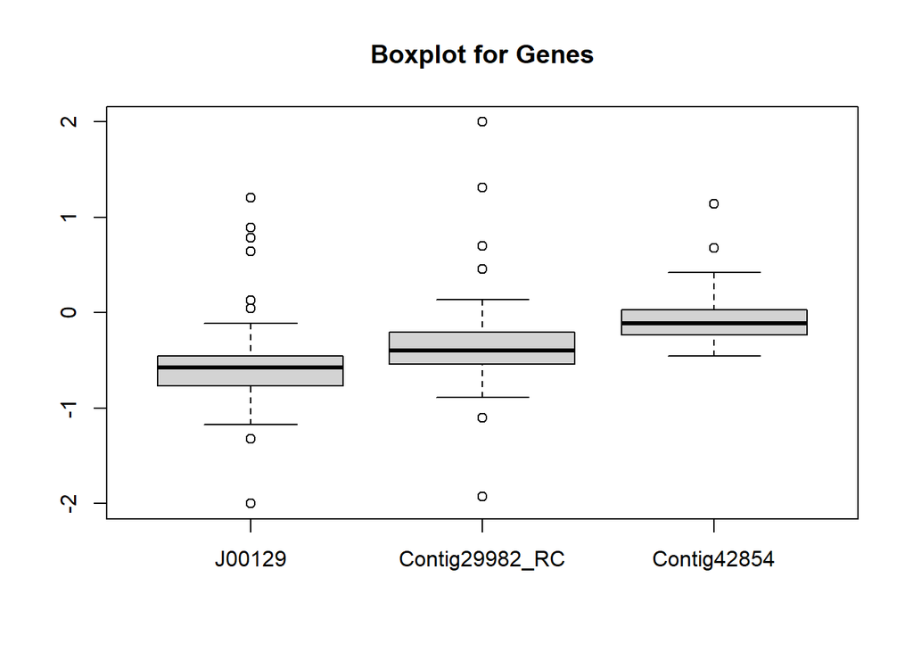

```r
# Identify outliers
# Example: Z-score method for identifying outliers in the first gene column
z_scores <- scale(processed_data[,1])
outliers <- which(abs(z_scores) > 3)

# Visualize outliers (for the first gene as an example)
boxplot(processed_data[,1:3], main="Boxplot for Genes")
```

**Statistical Measures & Analysis:**

```r
# Exclude the column with labels for invasive vs. noninvasive cancer if present
genes_data <- processed_data[, !names(processed_data) %in% c('class')]

# Calculate statistical measures
mean_values <- apply(genes_data, 2, mean)

median_values <- apply(genes_data, 2, median)

std_dev_values <- apply(genes_data, 2, sd)

variance_values <- apply(genes_data, 2, var)

range_values <- apply(genes_data, 2, function(x) max(x) - min(x))

statistical_measures <- data.frame(
  Mean = mean_values,
  Median = median_values,
  StandardDeviation = std_dev_values,
  Variance = variance_values,
  Range = range_values
)

# Display the statistical measures for the first gene column
# Assuming the first gene corresponds to the first column in the original data
first_gene_measures <- statistical_measures[1:5,]
print(first_gene_measures)
```

```
##                       Mean Median StandardDeviation   Variance Range
## J00129         -0.55766667 -0.574         0.4499578 0.20246199 3.206
## Contig29982_RC -0.33938462 -0.396         0.4673664 0.21843138 3.927
## Contig42854    -0.07625641 -0.110         0.2508432 0.06292232 1.593
## Contig42014_RC -0.03465385 -0.058         0.2094581 0.04387270 1.292
## Contig27915_RC -0.04126923 -0.090         0.2436339 0.05935750 1.127
```

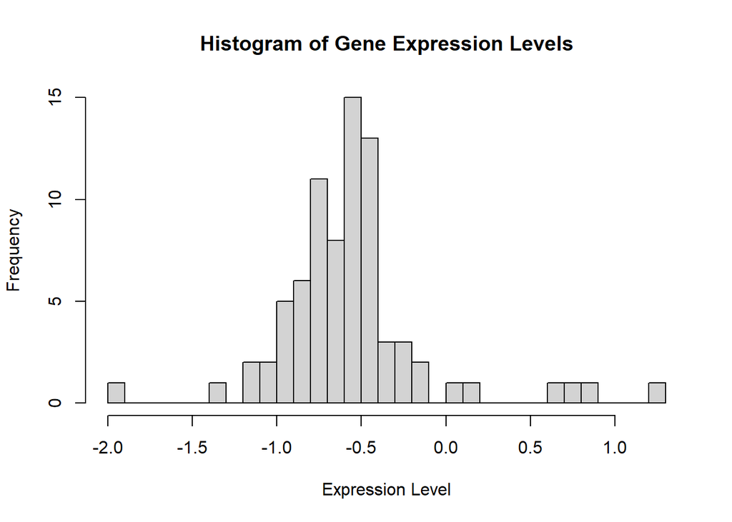

```r
# Distribution of gene expression levels - Histogram for a single gene as an example
hist(genes_data[,1], breaks = 30, main = "Histogram of Gene Expression Levels", xlab = "Expression Level", ylab = "Frequency")
```

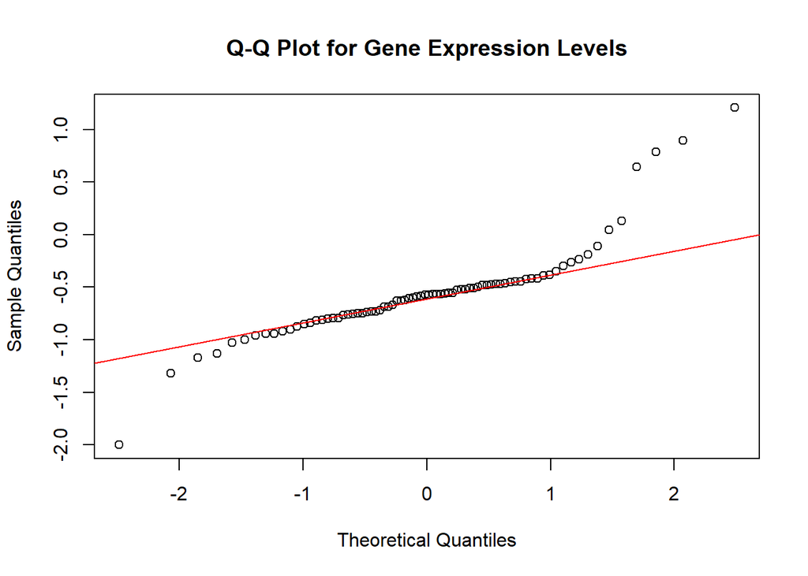

```r
# Assessing normality - Q-Q plot for the same gene as an example
qqnorm(genes_data[,1], main = "Q-Q Plot for Gene Expression Levels")
qqline(genes_data[,1], col = "red")
```

```r
# Assuming 'genes_data' is your cleaned and preprocessed dataset, excluding the label column

# Calculate variance for each gene
gene_variances <- apply(genes_data, 2, var)

# You can set a threshold for variance to filter genes
# For example, selecting genes with variance in the top 25%
variance_threshold <- quantile(gene_variances, 0.75)
high_variance_genes <- names(gene_variances[gene_variances > variance_threshold])

# Calculate the Coefficient of Variation (CV) for each gene
gene_means <- apply(genes_data, 2, mean)
gene_sd <- apply(genes_data, 2, sd)
gene_cv <- gene_sd / gene_means

# Optionally, filter genes based on CV
# For example, selecting genes with CV in the top 25%
cv_threshold <- quantile(gene_cv, 0.75)
high_cv_genes <- names(gene_cv[gene_cv > cv_threshold])

# Summary of results
cat("Number of genes with high variance:", length(high_variance_genes), "\n")
```

```
## Number of genes with high variance: 1237
```

```r
cat("Number of genes with high CV:", length(high_cv_genes), "\n")
```

```
## Number of genes with high CV: 1237
```

**Generating a Random Subset:**

```r
# Setting up random seed for reproducibility
registration_number <- 2315740 #Mantosh
set.seed(registration_number)

# Generating random subset of 2000 features
subset_indices <- sample(1:(ncol(initial_data) - 1), 2000)
subset_indices[1:20]
```

```
##  [1] 2692 2091 3641 2769 4909 1672 3200 1142 3892 2575 2307 1138  855 3066  334
## [16] 3848 1950 2667 3749 2881
```

```r
subset_df <- initial_data[ , subset_indices]

# Validating and understanding the random subset
dim(subset_df)
```

```
## [1]   78 2000
```

**Preprocessing the Randomly Generated Subset:**

```r
# Checking null values
na_count <- sum(is.na(subset_df))
na_count
```

```
## [1] 65
```

```r
# Replacing null values with column means
subset_df <- na.aggregate(subset_df, FUN = mean)

# Validating null values
na_count <- sum(is.na(subset_df))
na_count
```

```
## [1] 0
```

```r
# Checking for infinte values / error values
inf_count <- sum(sapply(subset_df, function(x) sum(is.infinite(x))))
inf_count
```

```
## [1] 0
```

**Understanding Correlation Between Variables:**

```r
# Craeting a correlation matrix
correlation <- cor(subset_df)

# Creating highly correlated pairs
highly_correlated_pairs <- which(correlation > 0.7 & correlation < 1, arr.ind = TRUE)

# Removing one feature for each pair
features_to_remove <- character(0)
for (i in 1:nrow(highly_correlated_pairs)) {
  feature1 <- colnames(subset_df)[highly_correlated_pairs[i, 1]]
  feature2 <- colnames(subset_df)[highly_correlated_pairs[i, 2]]
  if (!(feature1 %in% features_to_remove)) {
    features_to_remove <- c(features_to_remove, feature2)
  }
}

# Creating a filtered df with removed features
filtered_df <- subset_df[, !colnames(subset_df) %in% features_to_remove]
dim(filtered_df)
```

```
## [1]   78 1429
```

#### PART 1: Dimensionality Reduction:

**I) Consider unsupervised and supervised dimension reduction of the 2000 observed gene expression values in your data set.**

**Applying Principal Component Analysis for Dimensionality Reduction:**

```r
# Performing PCA while scaling the dataset
pca <- prcomp(filtered_df, scale. = TRUE , center = TRUE)
summary(pca)
```

```
## Importance of components:
##                            PC1    PC2     PC3     PC4     PC5     PC6     PC7
## Standard deviation     13.0223 9.8284 9.25056 8.76649 7.59301 6.76422 6.56015
## Proportion of Variance  0.1187 0.0676 0.05988 0.05378 0.04035 0.03202 0.03012
## Cumulative Proportion   0.1187 0.1863 0.24615 0.29993 0.34028 0.37230 0.40241
##                            PC8     PC9    PC10    PC11    PC12    PC13    PC14
## Standard deviation     6.43962 5.88419 5.55992 5.34519 5.21624 5.05868 4.80252
## Proportion of Variance 0.02902 0.02423 0.02163 0.01999 0.01904 0.01791 0.01614
## Cumulative Proportion  0.43143 0.45566 0.47729 0.49729 0.51633 0.53424 0.55038
##                           PC15    PC16    PC17    PC18    PC19    PC20   PC21
## Standard deviation     4.74818 4.66365 4.62757 4.53056 4.44574 4.36092 4.3106
## Proportion of Variance 0.01578 0.01522 0.01499 0.01436 0.01383 0.01331 0.0130
## Cumulative Proportion  0.56615 0.58137 0.59636 0.61072 0.62455 0.63786 0.6509
##                           PC22    PC23    PC24    PC25    PC26    PC27    PC28
## Standard deviation     4.21539 4.13073 4.07541 3.98923 3.96891 3.90878 3.84235
## Proportion of Variance 0.01243 0.01194 0.01162 0.01114 0.01102 0.01069 0.01033
## Cumulative Proportion  0.66330 0.67524 0.68686 0.69800 0.70902 0.71971 0.73005
##                           PC29    PC30    PC31    PC32    PC33    PC34    PC35
## Standard deviation     3.72961 3.70281 3.62993 3.61303 3.51768 3.47629 3.43040
## Proportion of Variance 0.00973 0.00959 0.00922 0.00914 0.00866 0.00846 0.00823
## Cumulative Proportion  0.73978 0.74937 0.75859 0.76773 0.77639 0.78485 0.79308
##                           PC36    PC37    PC38    PC39    PC40    PC41    PC42
## Standard deviation     3.37112 3.33194 3.31362 3.29383 3.22428 3.17435 3.15009
## Proportion of Variance 0.00795 0.00777 0.00768 0.00759 0.00727 0.00705 0.00694
## Cumulative Proportion  0.80103 0.80880 0.81649 0.82408 0.83135 0.83840 0.84535
##                           PC43    PC44    PC45    PC46    PC47    PC48    PC49
## Standard deviation     3.10326 3.05101 3.00554 2.98243 2.94585 2.92674 2.88405
## Proportion of Variance 0.00674 0.00651 0.00632 0.00622 0.00607 0.00599 0.00582
## Cumulative Proportion  0.85209 0.85860 0.86492 0.87115 0.87722 0.88322 0.88904
##                           PC50    PC51    PC52   PC53    PC54    PC55    PC56
## Standard deviation     2.85896 2.81952 2.78296 2.7791 2.76539 2.70510 2.67489
## Proportion of Variance 0.00572 0.00556 0.00542 0.0054 0.00535 0.00512 0.00501
## Cumulative Proportion  0.89476 0.90032 0.90574 0.9111 0.91649 0.92162 0.92662
##                           PC57   PC58    PC59    PC60    PC61    PC62    PC63
## Standard deviation     2.61270 2.5917 2.53919 2.49525 2.45853 2.42539 2.40288
## Proportion of Variance 0.00478 0.0047 0.00451 0.00436 0.00423 0.00412 0.00404
## Cumulative Proportion  0.93140 0.9361 0.94061 0.94497 0.94920 0.95332 0.95736
##                           PC64    PC65    PC66    PC67    PC68    PC69    PC70
## Standard deviation     2.35260 2.29672 2.28423 2.23989 2.19872 2.14353 2.09731
## Proportion of Variance 0.00387 0.00369 0.00365 0.00351 0.00338 0.00322 0.00308
## Cumulative Proportion  0.96123 0.96492 0.96857 0.97208 0.97547 0.97868 0.98176
##                           PC71    PC72   PC73    PC74    PC75    PC76    PC77
## Standard deviation     2.06713 2.02591 2.0012 1.94920 1.89281 1.80437 1.74541
## Proportion of Variance 0.00299 0.00287 0.0028 0.00266 0.00251 0.00228 0.00213
## Cumulative Proportion  0.98475 0.98762 0.9904 0.99308 0.99559 0.99787 1.00000
##                             PC78
## Standard deviation     5.783e-15
## Proportion of Variance 0.000e+00
## Cumulative Proportion  1.000e+00
```

```r
# Analyzing the structure of PCA
str(pca)
```

```
## List of 5
##  $ sdev    : num [1:78] 13.02 9.83 9.25 8.77 7.59 ...
##  $ rotation: num [1:1429, 1:78] -0.0222 -0.0257 -0.036 -0.0214 0.0295 ...
##   ..- attr(*, "dimnames")=List of 2
##   .. ..$ : chr [1:1429] "NM_016073" "NM_004864" "NM_006006" "NM_016371" ...
##   .. ..$ : chr [1:78] "PC1" "PC2" "PC3" "PC4" ...
##  $ center  : Named num [1:1429] -0.031 -0.322 -0.1299 -0.0994 -0.0215 ...
##   ..- attr(*, "names")= chr [1:1429] "NM_016073" "NM_004864" "NM_006006" "NM_016371" ...
##  $ scale   : Named num [1:1429] 0.157 0.445 0.383 0.208 0.137 ...
##   ..- attr(*, "names")= chr [1:1429] "NM_016073" "NM_004864" "NM_006006" "NM_016371" ...
##  $ x       : num [1:78, 1:78] -13.14 -9.99 -1.32 1.01 -5.24 ...
##   ..- attr(*, "dimnames")=List of 2
##   .. ..$ : NULL
##   .. ..$ : chr [1:78] "PC1" "PC2" "PC3" "PC4" ...
##  - attr(*, "class")= chr "prcomp"
```

**Plotting Explained and Cumulative Variance for Each Principal Component:**

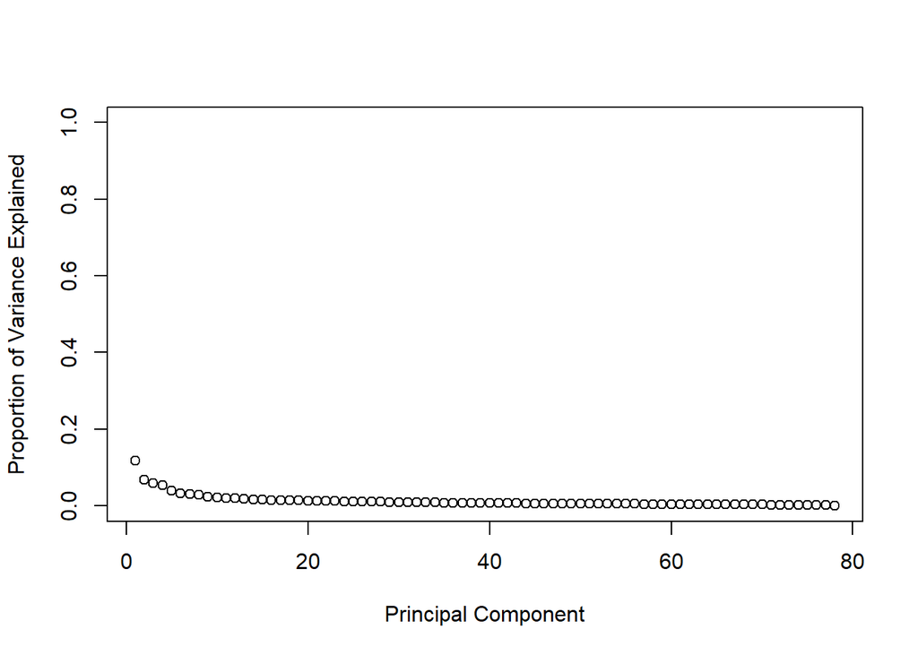

```r
pca.var <- pca$sdev^2
pve <- pca.var / sum(pca.var)

# Plotting variance explained for each principal component
plot(pve,
     xlab = "Principal Component",
     ylab = "Proportion of Variance Explained",
     ylim = c(0,1),
     type = "b")
```